# Characterizing Automobiles

Author

Published

March 17, 2025

# Setup

- Setup

```r
sh <- suppressPackageStartupMessages
sh(library(tidyverse))
sh(library(caret))
sh(library(fastDummies))
sh(library(class))
sh(library(ISLR)) # for the "Auto" dataframe
```

# Dataframe

- We use the `Auto` dataframe.

```r
head(Auto)
```

```
  mpg cylinders displacement horsepower weight acceleration year origin
1  18         8          307        130   3504         12.0   70      1
2  15         8          350        165   3693         11.5   70      1
3  18         8          318        150   3436         11.0   70      1
4  16         8          304        150   3433         12.0   70      1
5  17         8          302        140   3449         10.5   70      1
6  15         8          429        198   4341         10.0   70      1
                       name
1 chevrolet chevelle malibu
2         buick skylark 320
3        plymouth satellite
4             amc rebel sst
5               ford torino
6          ford galaxie 500
```

- It has the following variable names, which describe various attributes of automobiles.

```r
names(Auto)
```

```
[1] "mpg"          "cylinders"    "displacement" "horsepower"   "weight"
[6] "acceleration" "year"         "origin"       "name"
```

# Multiple Regression

- Run a linear regression model with `mpg` as the dependent variable and `horsepower` and `year` as features (variables).
- Compute and comment on the RMSE.

```r
set.seed(28213)
auto_index <- createDataPartition(Auto$year, p = 0.8, list = FALSE)
train <- Auto[auto_index,]
test <- Auto[-auto_index,]


linear = lm(mpg ~ horsepower + year, data = train)
summary(linear)
```

```
Call:
lm(formula = mpg ~ horsepower + year, data = train)

Residuals:
     Min       1Q   Median       3Q      Max
-12.1925  -3.1075  -0.1425   2.7127  15.3607

Coefficients:
              Estimate Std. Error t value Pr(>|t|)
(Intercept) -10.343699   6.072100  -1.703   0.0895 .
horsepower   -0.130877   0.007097 -18.440  < 2e-16 ***
year          0.626125   0.075135   8.333 2.53e-15 ***
---
Signif. codes:  0 '***' 0.001 '**' 0.01 '*' 0.05 '.' 0.1 ' ' 1

Residual standard error: 4.481 on 312 degrees of freedom
Multiple R-squared:  0.682, Adjusted R-squared:   0.68
F-statistic: 334.5 on 2 and 312 DF,  p-value: < 2.2e-16
```

```r
predictions = predict(linear, newdata = test)
residuals = test$mpg - predictions

rmse = sqrt(mean(residuals^2))
cat("RMSE:", rmse, "\nMin. MPG:", min(Auto$mpg), "\n Max MPG:", max(Auto$mpg), "\n Median MPG:", median(Auto$mpg), "\nSD MPD:", sd(Auto$mpg))
```

```
RMSE: 4.008855
Min. MPG: 9
 Max MPG: 46.6
 Median MPG: 22.75
SD MPD: 7.805007
```

> EXPLAIN: So in this simple linear model, the RMSE is only about 4, which means if it tries to predict a car’s mpg, based only on its horsepower and manufacture year, it’ll only be off by an average of 4 miles per gallon. In the scheme of the spread of this dataset, that honestly seems really great. The standard deviation of mpg is nearly 8, so the RMSE being about half that makes this simple model appear to be a surprisingly good predictor for mpg.

# Feature Engineering

- Create 10 features based on the `name` column.
- Remove all rows with a missing value.
- Ensure only `mpg` and the engineered features remain.
- Compute and comment on the RMSE.

```r
#somehow it was a factor?
Auto$name = as.character(Auto$name)

#making new columns
feat_auto = Auto %>%
  mutate(
    american = str_detect(name,"chevrolet|buick|plymouth|amc|ford|pontiac|dodge|chrysler|mercury|oldsmobile|cadillac|chevy|chevroelt"),
    japanese = str_detect(name, "toyota|datsun|honda|mazda|subaru|nissan|toyouta|maxda|hi"),
    german = str_detect(name, "volkswagen|bmw|audi|mercedes-benz|mercedes|vokswagen|opel|capri|vw"),
    french = str_detect(name, "peugeot|renault"),
    italian = str_detect(name, "fiat"),
    swedish = str_detect(name, "volvo|saab"),
    british = str_detect(name, "triumph"),
    diesel = str_detect(name, "diesel"),
    stationwagon = str_detect(name, "(sw)"),
    luxury = str_detect(name, "bmw|mercedes-benz|mercedes|audi|cadillac")
  )

#final narrowing it down before computing rmse
feat_auto_mod = feat_auto %>%
  select(name, mpg, american, japanese, german, french, italian, swedish, british, diesel, stationwagon, luxury) %>%
  drop_na()

#let's do it!
set.seed(887)
auto_index <- createDataPartition(feat_auto_mod$mpg, p = 0.8, list = FALSE)
train <- feat_auto_mod[auto_index,]
test <- feat_auto_mod[-auto_index,]

feature = lm(mpg ~ american + japanese + german + french + italian + swedish + british + diesel + stationwagon + luxury, data = train)
summary(feature)
```

```
Call:
lm(formula = mpg ~ american + japanese + german + french + italian +
    swedish + british + diesel + stationwagon + luxury, data = train)

Residuals:
     Min       1Q   Median       3Q      Max
-21.2073  -4.4333  -0.5333   3.7781  18.6120

Coefficients:
                 Estimate Std. Error t value Pr(>|t|)
(Intercept)       31.0815     2.8003  11.100  < 2e-16 ***
americanTRUE     -10.6935     2.7292  -3.918  0.00011 ***
japaneseTRUE      -0.8743     2.8531  -0.306  0.75949
germanTRUE        -0.3903     2.4161  -0.162  0.87178
frenchTRUE        -6.2932     3.3218  -1.895  0.05911 .
italianTRUE       -2.0387     3.6642  -0.556  0.57836
swedishTRUE      -10.1545     3.7827  -2.684  0.00766 **
britishTRUE        3.9185     6.8509   0.572  0.56777
dieselTRUE        11.7378     2.6841   4.373 1.69e-05 ***
stationwagonTRUE  -2.9547     1.2340  -2.394  0.01725 *
luxuryTRUE        -5.9489     2.3576  -2.523  0.01214 *
---
Signif. codes:  0 '***' 0.001 '**' 0.01 '*' 0.05 '.' 0.1 ' ' 1

Residual standard error: 6.252 on 304 degrees of freedom
Multiple R-squared:  0.3779,    Adjusted R-squared:  0.3575
F-statistic: 18.47 on 10 and 304 DF,  p-value: < 2.2e-16
```

```r
predictions = predict(feature, newdata = test)
residuals = test$mpg - predictions

rmse = sqrt(mean(residuals^2))
cat("RMSE:", rmse)
```

```
RMSE: 5.547203
```

> EXPLAIN: Using these new features, which were mostly just sorted by country of origin, the RMSE got slightly worse, though I think it still borders on “acceptable” in terms of explaining the mpg for a car. Whether or not the car was a stationwagon or used diesel seemed to be the best predictors, which makes obvious intuitive sense! Swedish and American cars seemed oddly terrible in terms of mpg overall, while Japanese, British, and German trended towards being great. Many countries just lacked much data, so maybe I’d combine some European countries (besides Germany) in the future.

# Classification

- Use either of $K$-NN or Naive Bayes to predict whether an automobile is a `chevrolet` or a `honda`.
- Explain your choice of technique.
- Report on your Kappa value.

```r
#i'm not sure if this is good (don't wanna classify everything as a honda) or bad (overfitting)
auto_knn = Auto %>%
  mutate(make = word(name, 1)) %>%
  filter(make %in% c("chevrolet","chevy","chevroelt","honda")) %>%
  drop_na() %>%
  mutate(make = case_when(
    make %in% c("chevy","chevroelt") ~ "chevrolet",
    TRUE ~ make
  ))

#i just realized the 'origin' column exists. that invalidates all my previous features. and will make this model so overfit. i think i'm gonna drop it if my kappa is too high. maybe boxcox will destroy it?

auto_knn = auto_knn %>%
  select(-name, -origin)

#boxcox
auto_box <- auto_knn %>%
  preProcess(method = c("BoxCox","center","scale")) %>%
  predict(auto_knn)

#knn
set.seed(9841)
auto_index <- createDataPartition(auto_box$make, p = 0.7, list = FALSE)
train <- auto_box[auto_index,]
test <- auto_box[-auto_index,]

model <- train(make ~ .,
             data = train,
             method = "knn",
             tuneLength = 15,
             trControl = trainControl(method = "cv", number = 5))
print(model)
```

[output not shown]

```r
confusionMatrix(predict(model,test), factor(test$make))
```

```
Confusion Matrix and Statistics

           Reference
Prediction  chevrolet honda
  chevrolet        13     0
  honda             1     3

               Accuracy : 0.9412
                 95% CI : (0.7131, 0.9985)
    No Information Rate : 0.8235
    P-Value [Acc > NIR] : 0.1711

                  Kappa : 0.8211

 Mcnemar's Test P-Value : 1.0000

            Sensitivity : 0.9286
            Specificity : 1.0000
         Pos Pred Value : 1.0000
         Neg Pred Value : 0.7500
             Prevalence : 0.8235
         Detection Rate : 0.7647
   Detection Prevalence : 0.7647
      Balanced Accuracy : 0.9643

       'Positive' Class : chevrolet
```

> EXPLAIN: Ok this was a bit of a mess. I filtered to only include Chevys and Hondas after a lot of deliberation. The origin column would especially be a huge problem when it came to overfitting, so I dropped it. When I initially partitioned the train/test at 0.8, I always got a kappa of 1, so putting it down to 0.7 gave me a more realistic/awesome kappa of ~0.8. This may be due to the relative scarcity of Hondas in the dataset compared to Chevys? I was initially very hesitant to filter it to only Chevys or Hondas, but I think that’s the only way this kind of model would work, after testing a little extra.

# Binary Classification

- Predict whether a car is a `honda`.
- Use model weights.
- Display and comment on an ROC curve.

```r
auto_binary = Auto %>%
  mutate(honda = str_detect(name, "honda") %>% as.factor()) %>%
  drop_na() %>%
  select(-name)
#i think it's ok to leave origin in since there are other japanese manufacturers

set.seed(117)
auto_index <- createDataPartition(auto_binary$honda, p = 0.8, list = FALSE)
train <- auto_binary[auto_index,]
test <- auto_binary[-auto_index,]

#all hondas are from japan and have 4 cylinders!
weight_train = train %>%
  mutate(weights=case_when(origin==3 & cylinders == 4 ~ 10,
                           TRUE ~ 1))

#random forest...
control = trainControl(method = "cv", number = 5)

fit <- train(honda ~ .,
             data = train,
             trControl = control,
             method = "rf",
             maxit = 10,
             weights = weight_train$weights)
print(fit)
```

```
Random Forest

315 samples
  8 predictor
  2 classes: 'FALSE', 'TRUE'

No pre-processing
Resampling: Cross-Validated (5 fold)
Summary of sample sizes: 252, 252, 251, 252, 253
Resampling results across tuning parameters:

  mtry  Accuracy   Kappa
  2     0.9714254  0.3261586
  5     0.9746000  0.4580505
  8     0.9650762  0.3662355

Accuracy was used to select the optimal model using the largest value.
The final value used for the model was mtry = 5.
```

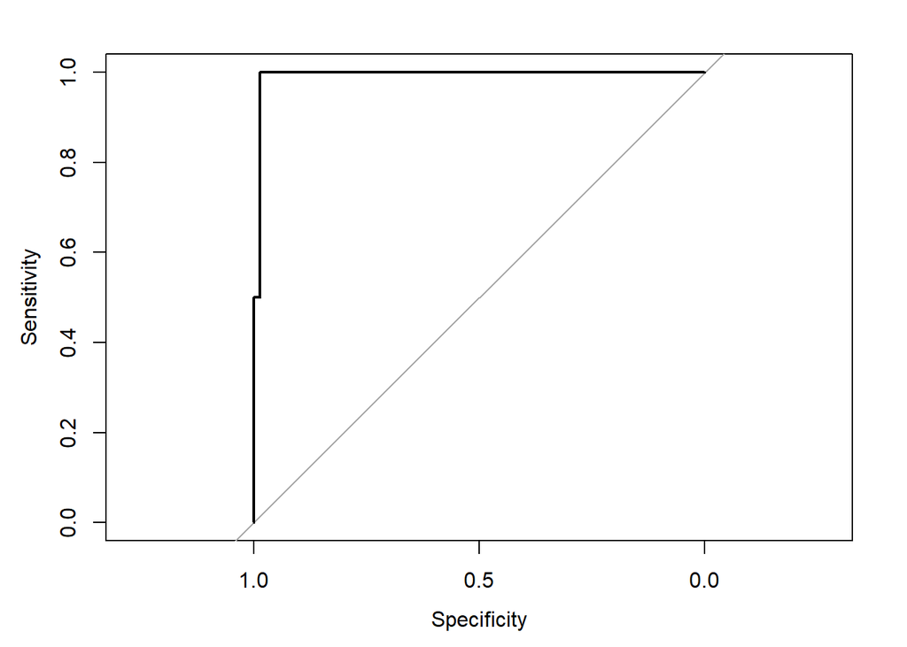

```r
#roc
library(pROC)
prob <- predict(fit, newdata = test, type = "prob")[,2]
myRoc <- roc(test$honda, prob)
plot(myRoc)
```

```r
auc(myRoc)
```

```
Area under the curve: 0.9933
```

> EXPLAIN: Using a random forest, I got a kappa of 0.45. I gave extra weight to cars with 4 cylinders and an origin of 3 (Japan), which all hondas share. I’m decently satisfied… The AUC was a whopping 0.9933. This makes me wonder about overfitting, but the kappa makes me question that.